# data2002 practice

Jing Yang 480110301

10/16/2020

```r
library(tidyverse)
library(lubridate)
library(forcats)
library(skimr)
library(plotly)
library(ggpubr)
library(kableExtra)
library(gridExtra)
mykable <- function(dt, ...) {
  kbl(dt, ...) %>% kable_material(c("striped", "hover", "condensed", "responsive"), full_width = F)
}
```

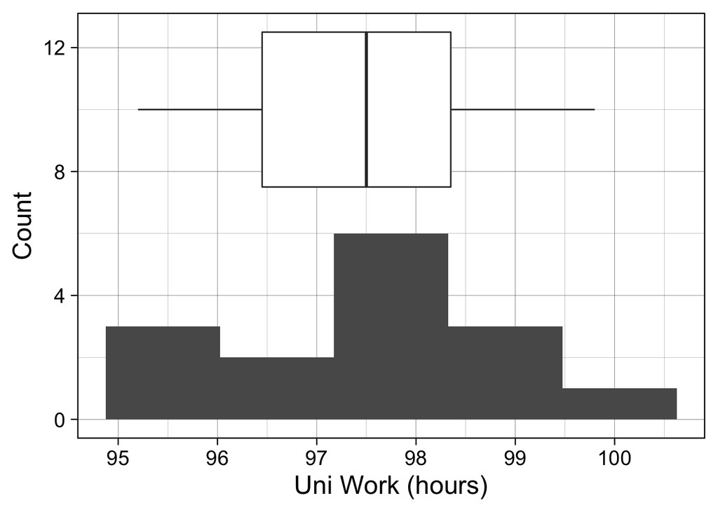

```r
x = c(97.5, 95.2, 97.3, 96.0, 96.8, 99.8, 97.4, 95.3, 98.2, 99.1, 96.1, 97.6, 98.2, 98.5, 99.4)

data = as.data.frame(x)
ggplot(data, aes(x= x)) +
  geom_histogram(bins = 5, show.legend = F) +
  theme_linedraw(base_size = 18) +
  labs(y = "Count", x = "Uni Work (hours)") +
  geom_boxplot(aes(x = x, y = 10), outlier.alpha = 0.5, width = 5)
```

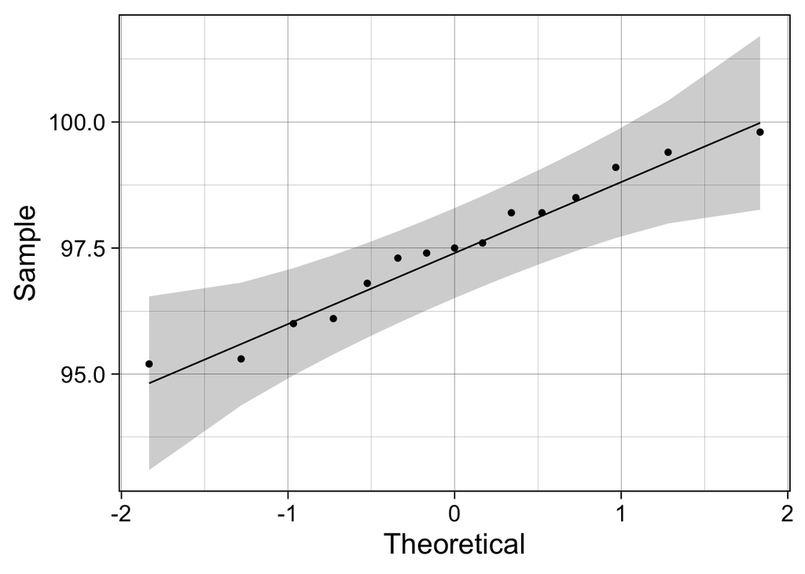

```r
ggqqplot(data, x = "x") +
  theme_linedraw(base_size = 18) + theme(legend.position = "none")
```

```r
mu = 96
diff = data$x-mu
n = length(sign(diff)[sign(diff) != 0])
freq = as.vector(table(sign(diff)[sign(diff) != 0]))

# binom.test(freq,p=0.5,alternative="greater")
t0 =  length(diff[diff>0])
pval = binom.test(t0,n,p=0.5,alternative="greater")$p.value
```

**Hypothesis:** $H_0:\mu=96$ vs $H_1:\mu>96, \mu<96,\mu \neq 96$

**Assumptions:** Observations are indeendently sampled from a symmetric distribution.

**Test statistic:**
$$T=number~of (D_i>0)$$
where $D_i=X_i-96$. Under $H_0$, the test statistic follows a binomial distribution with identity $B(n,\frac{1}{2})$ where n is the number of non-zero differences.

**Observed test statistic:** $t_0=number~of(d_i>0)=12$

**P-value:**

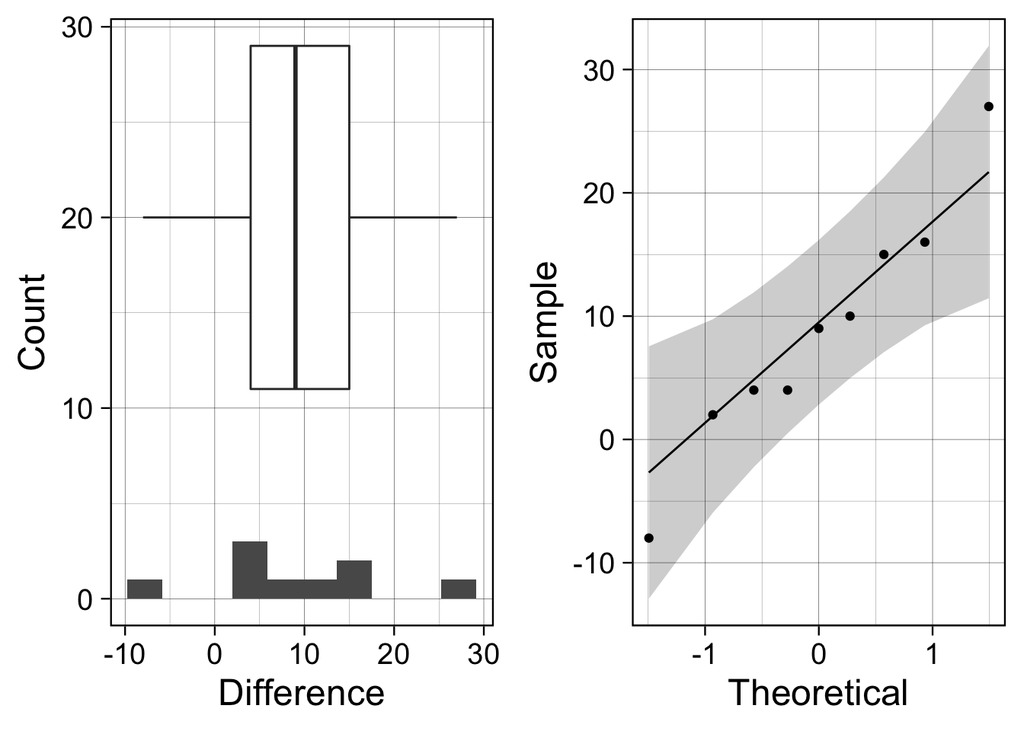

```r
before = c(25, 25, 27, 44, 30, 67, 53, 53, 52)
after = c(27, 29, 37, 36, 46, 82, 57, 80, 61)
df = data.frame(before, after,diff = after-before)

p1 = ggplot(df, aes(x= diff)) +
  geom_histogram(bins = 10, show.legend = F) +
  theme_linedraw(base_size = 18) +
  labs(y = "Count", x = "Difference") +
  geom_boxplot(aes(x = diff, y = 20), outlier.alpha = 0.5, width = 18)

p2 = ggqqplot(df, x = "diff") +
  theme_linedraw(base_size = 18) + theme(legend.position = "none")

grid.arrange(p1, p2, ncol=2)
```

**Hypothesis:** $H_0:p_+=\frac{1}{2}$ vs $H_1:p_+>\frac{1}{2}$

**Assumptions:** Differences $D_i$ are independent.

```r
before = c(44,60,25,25,53,52,27,67,28,30,53)
after = c(36,59,27,29,57,61,37,82,43,46,80)
df = data.frame(before,after, diff = after-before)

n = length(df$diff)

freq = as.vector(table(sign(df$diff)[sign(df$diff) != 0]))

t0 =  sum(df$diff>0)

binom.test(t0,n,p=0.5,alternative="greater")
```

```
##
##  Exact binomial test
##
## data:  t0 and n
## number of successes = 9, number of trials = 11, p-value = 0.03271
## alternative hypothesis: true probability of success is greater than 0.5
## 95 percent confidence interval:
##  0.5299132 1.0000000
## sample estimates:
## probability of success
##              0.8181818
```

```r
pval = binom.test(t0,n,p=0.5,alternative="greater")$p.value
```

**Test statistic:** Let $T$ be the number of positive differenceso out of the 11 non-zero differences. Under $H_0$, the test statistic follows a binomial distribution with the identity $B(11,\frac{1}{2})$.

**Observed test statistic:** We observed $t_0=9$ positive differences in the sample.

**P-value:** probability of getting a test statistic as or more extreme than what we observed, $P(T \geq 9)=1-P(T \leq 8)=1-pbinom(8,size=11,prob=\frac{1}{2})\approx 0.0327$

**Conclusion:**